# 2.2.1 HT1080 LOY vs sgCTRL — RNA-seq base analysis

## Top 20 Up — with PARENTAL

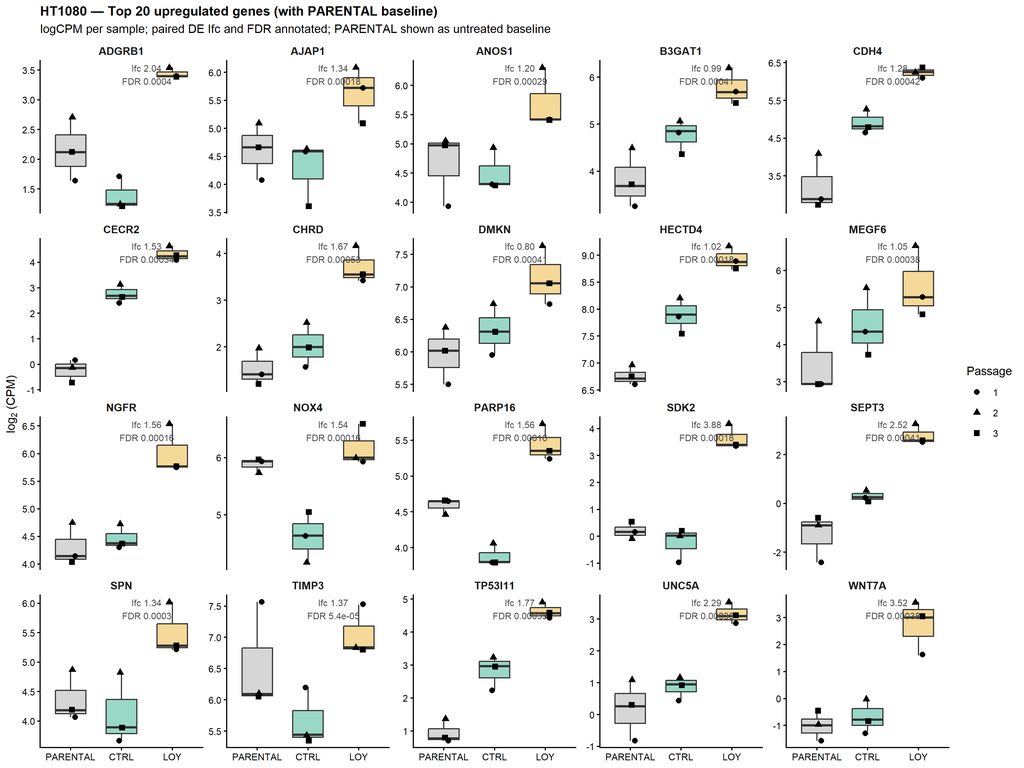

```
## Saved: boxplots_top20_up_with_parental.(png|pdf)  [12x9 in]
```

## Top 20 Down — with PARENTAL

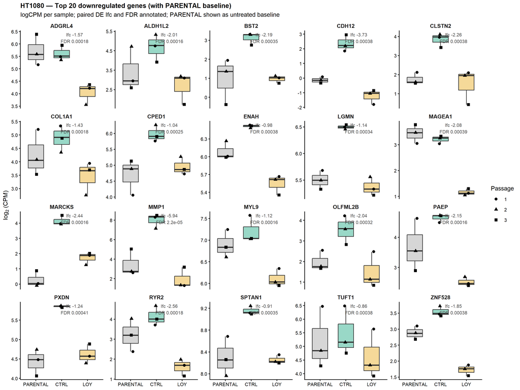

```
## Saved: boxplots_top20_down_with_parental.(png|pdf)  [12x9 in]
```

# 11. LOY vs combined controls (PARENTAL + sgCTRL)

**PARENTAL and sgCTRL samples are pooled** as a single Y+ baseline (n = 6) and contrasted against **LOY** (n = 3). The motivation: if the sgRNA treatment itself has no measurable effect (which we expect for a non-targeting guide), pooling gives more statistical power to detect LOY-driven changes. The cost is that any residual sgRNA-specific effect is folded into the baseline noise; section 4’s paired sgCTRL-only contrast remains the primary analysis. This section is the complementary view.

## 11.1 Pooled-design setup

```
## Removing 9 Y chromosome genes
```

```
## Pooled design: 6 Y_POS (PARENTAL + CTRL) vs 3 Y_NEG (LOY)
```

## 11.2 DE: limma-voom

Unpaired design — `Y_POS` contributes two samples per passage (one PARENTAL + one CTRL), so there is no clean within-passage blocking structure. The passage covariate from section 4’s paired model is intentionally dropped here.

```
## Design columns: Y_POS, Y_NEG
```

```
##
## LOY vs pooled Y+ baseline: 14457 genes tested
```

```
##   FDR < 0.05:              36
```

```
##   FDR < 0.05 & |logFC| > 0.75:  36 (up: 30, down: 6)
```

## 11.3 Volcano

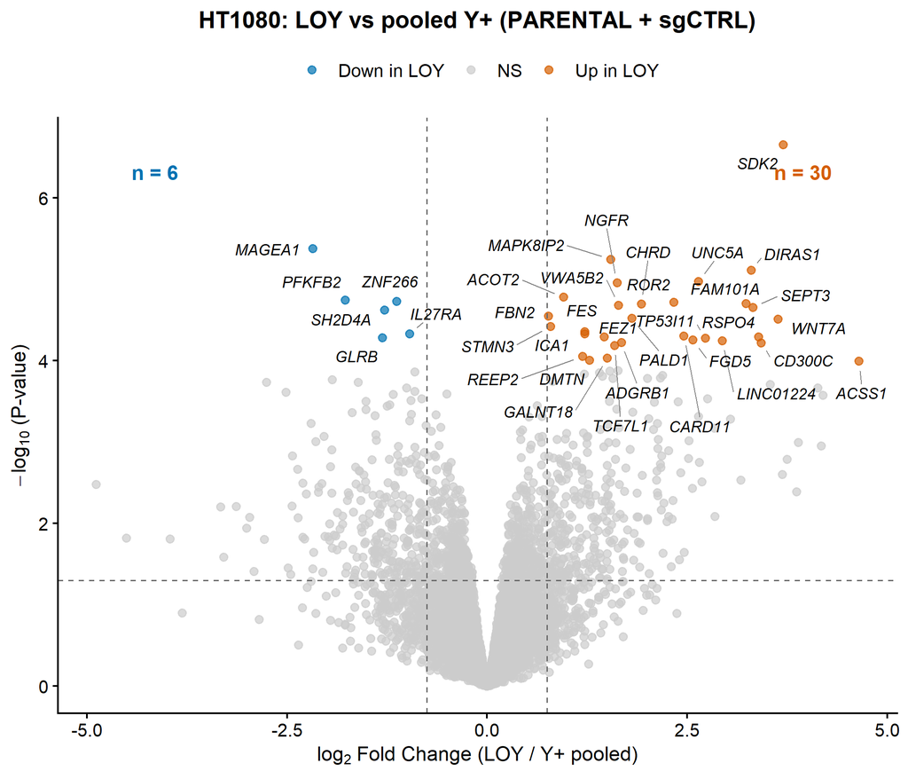

```
## Saved: volcano_LOY_v_pooled.(png|pdf)  [7x6 in]
```

## 11.4 fgsea (basic collections)

```
## Pooled ranks: 14363 genes (after RPS/RPL filter)
```

```
## Running fgsea (basic collections) for LOY vs pooled Y+...
```

```
##   Running hallmark (50 gene sets)...
##   Running reactome (1787 gene sets)...
##   Running kegg (186 gene sets)...
##   Running go_bp (7583 gene sets)...
```

LOY vs pooled Y+ — Significant pathways by collection

| collection | total | sig_up | sig_down |
| --- | --- | --- | --- |
| go_bp | 3574 | 14 | 61 |
| hallmark | 50 | 2 | 13 |
| kegg | 162 | 1 | 3 |
| reactome | 985 | 21 | 24 |

## 11.5 GSEA dotplot (pooled)

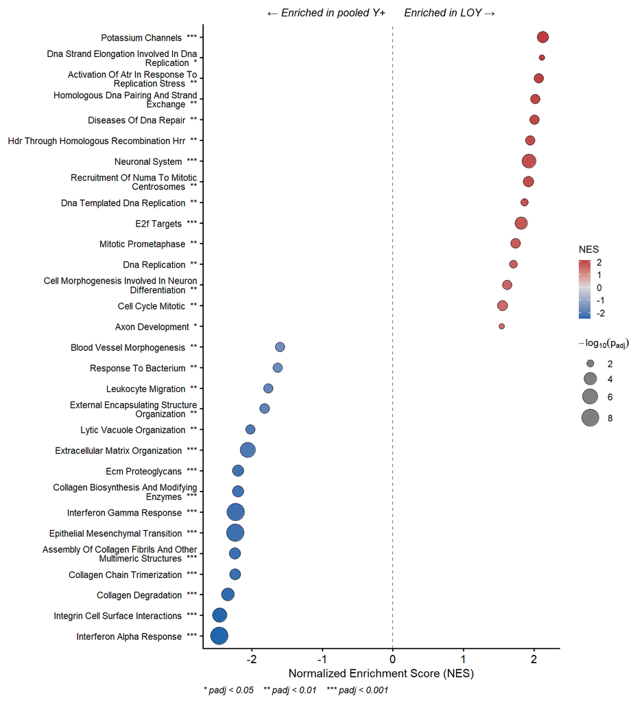

```
## Saved: gsea_dotplot_pooled.(png|pdf)  [5.5x6 in]
```

## 11.6 Hit concordance: paired sgCTRL vs pooled Y+

How well do the two contrasts agree? If the sgRNA control behaves like the parental, the pooled contrast should sharpen the statistics without changing the qualitative picture.

```
## Paired LOY-vs-sgCTRL DEGs:  505
```

```
## Pooled LOY-vs-Y+ DEGs:      36
```

```
## Intersection:                36
```

```
## Paired-only:                 469
```

```
## Pooled-only:                 0
```

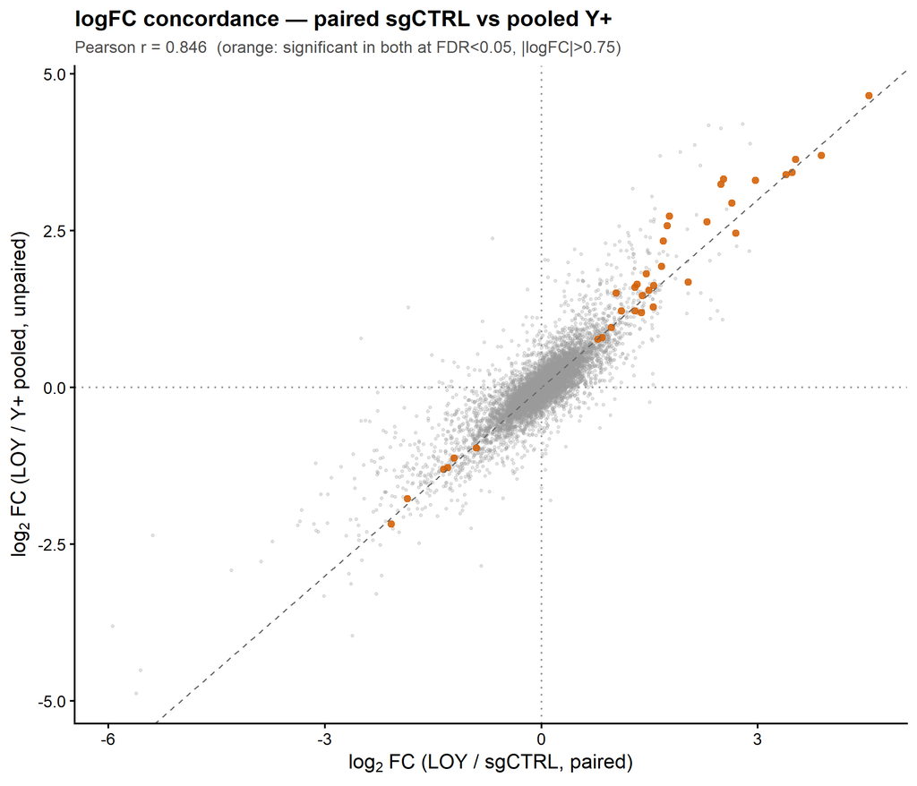

```
## Saved: concordance_paired_v_pooled.(png|pdf)  [7x6 in]
```

## 11.7 All-significant-pathways dotplot (no top-N cap)

Complement to §11.5: instead of the top-15-per-direction view, this shows **every** pathway across all four collections (Hallmark, Reactome, KEGG, GO:BP) that reaches `padj < 0.05` in the pooled contrast. With ~9,600 tested gene sets, this surfaces the full enrichment landscape — useful for spotting secondary signals the top-30 cut hides.

The helpers defined here are reused below for PRC2 (§11.8) and for the PARENTAL-vs-sgCTRL section (§12).

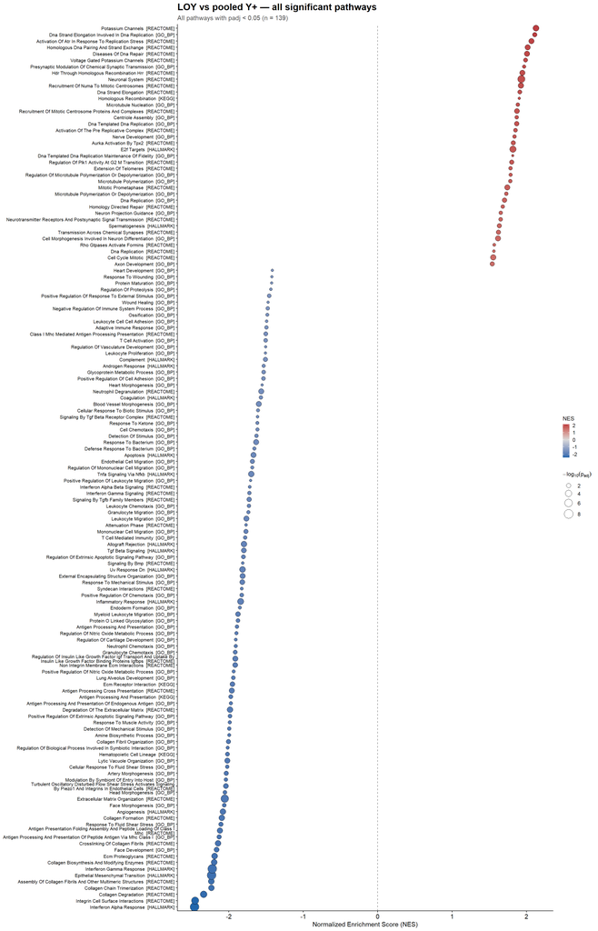

```
## Saved: gsea_all_sig_pooled.(png|pdf)  [9x14 in]
```

## 11.8 PRC2 / H3K27me3 pathway check (pooled)

Targeted view: pathways with `PRC2`, `H3K27`, `EZH2`, `EED`, `SUZ12`, or `POLYCOMB` in the name. These test whether the pooled contrast carries the same Polycomb-axis signal that the canonical sgCTRL contrast surfaces in §7 (albeit on the basic, not the expanded CGP, collections).

```
## PRC2 / H3K27me3-related pathways tested: 1 (significant at padj < 0.05: 0)
```

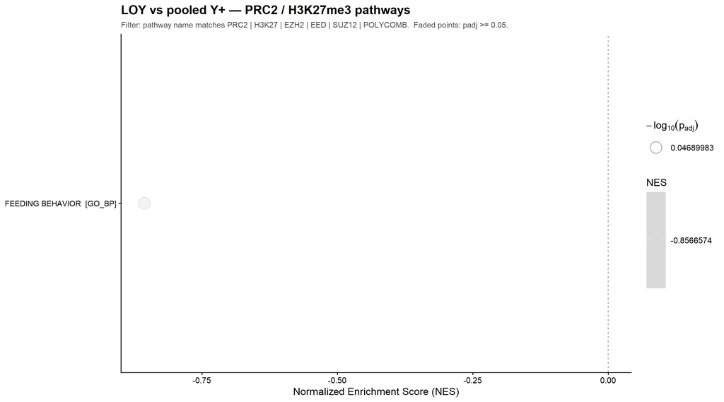

```
## Saved: gsea_prc2_pooled.(png|pdf)  [9x5 in]
```

## 11.9 TF activity panel (DoRothEA + decoupleR) — pooled

The same TF infrastructure used in §9 (DoRothEA A/B/C regulons + decoupleR CollecTRI network), but applied to the pooled-contrast t-statistics. Helper functions defined here are reused in §12 and §13.

```
## DoRothEA fgsea (pooled): 239 TFs tested, 5 significant (padj<0.05)
```

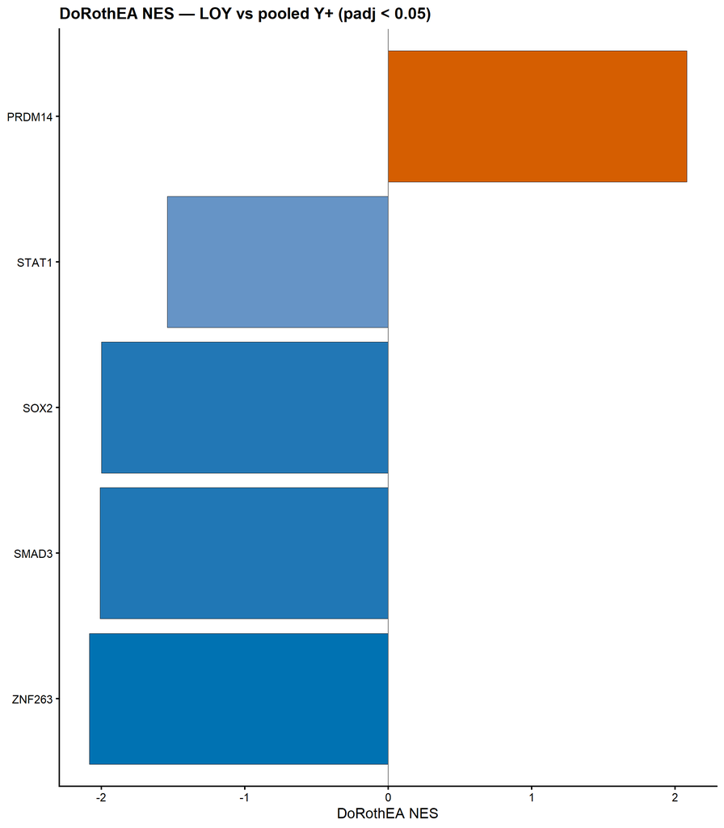

```
## Saved: tf_dorothea_bar_LOY_v_pooled.(png|pdf)  [7x8 in]
```

## 11.10 decoupleR contrast-level TF activity — pooled

```
## decoupleR contrast ULM (pooled): 660 TFs scored, 105 at p<0.05
```

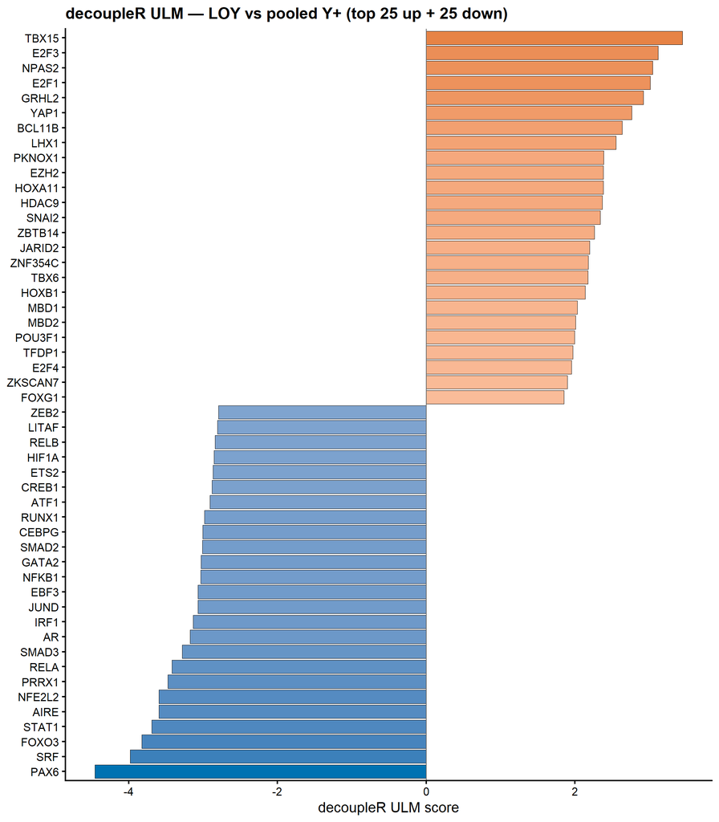

```
## Saved: decouple_TF_barplot_LOY_v_pooled.(png|pdf)  [7x8 in]
```

# 12. PARENTAL vs sgCTRL (sgRNA-control sanity check)

This contrast tests whether the **sgRNA control itself perturbs expression** relative to the unmodified parental population. A clean sgCTRL behaves like PARENTAL — few or no DEGs, no enriched programs — and that’s the assumption underlying §11’s pooled design. If this section produces many hits, the pooled-control analysis (§11) should be interpreted with caution and the §4 paired sgCTRL contrast remains the more conservative choice.

## 12.1 Setup

```
## Removing 9 Y chromosome genes
```

```
## PARENTAL-vs-CTRL working set: 6 samples (PARENTAL / CTRL)
```

## 12.2 DE: paired (treatment + passage)

```
##
## sgCTRL vs PARENTAL: 14457 genes tested
```

```
##   FDR < 0.05:              809
```

```
##   FDR < 0.05 & |logFC| > 0.75:  513 (up: 295, down: 218)
```

## 12.3 Volcano

[figure not shown]

```
## Saved: volcano_sgCTRL_v_PARENTAL.(png|pdf)  [7x6 in]
```

## 12.4 fgsea + dotplot (top 30)

```
## sgCTRL-vs-PARENTAL ranks: 14363 genes (after RPS/RPL filter)
```

```
## Running fgsea for sgCTRL vs PARENTAL...
```

```
##   Running hallmark (50 gene sets)...
##   Running reactome (1787 gene sets)...
##   Running kegg (186 gene sets)...
##   Running go_bp (7583 gene sets)...
```

sgCTRL vs PARENTAL — Significant pathways by collection

| collection | total | sig_up | sig_down |
| --- | --- | --- | --- |
| go_bp | 3574 | 10 | 231 |
| hallmark | 50 | 3 | 17 |
| kegg | 162 | 3 | 6 |
| reactome | 985 | 2 | 18 |

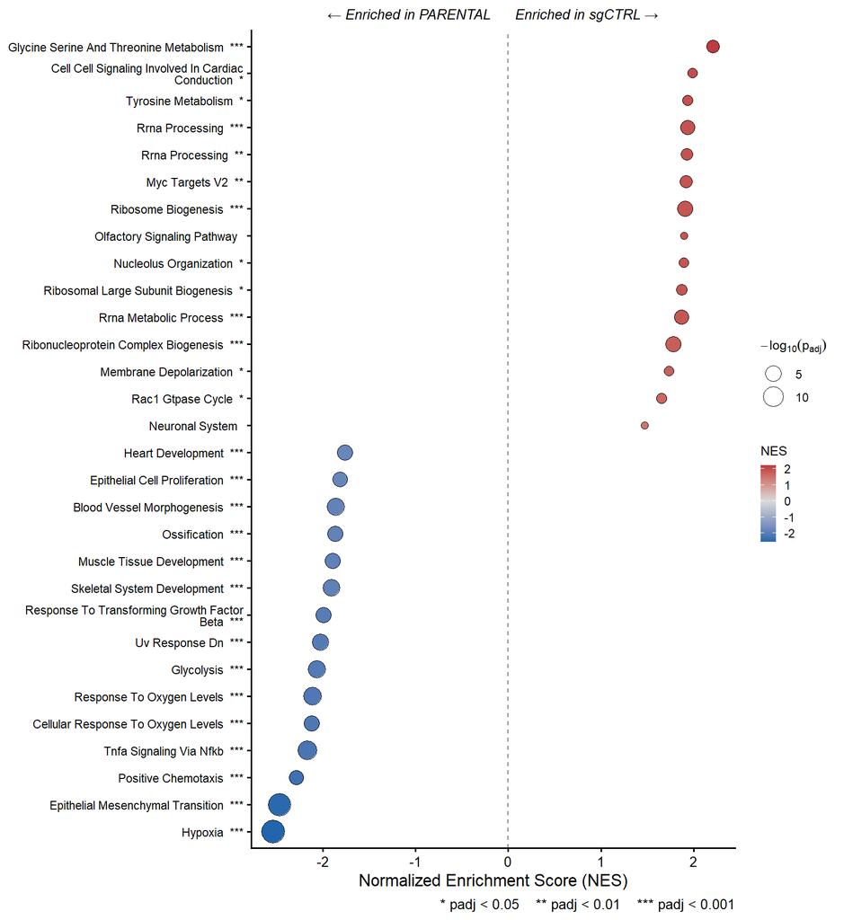

```
## Saved: gsea_dotplot_sgCTRL_v_PARENTAL.(png|pdf)  [5.5x6 in]
```

## 12.5 All-significant-pathways dotplot

[figure not shown]

```
## Saved: gsea_all_sig_sgCTRL_v_PARENTAL.(png|pdf)  [9x14 in]
```

## 12.6 PRC2 / H3K27me3 pathway check

Critical sanity check: if PRC2-axis pathways move between PARENTAL and sgCTRL, the LOY-vs-sgCTRL Polycomb story in §7 is partly confounded by the sgRNA treatment itself. We expect NO significant PRC2 enrichment here.

```
## PRC2 / H3K27me3-related pathways tested: 1 (significant at padj < 0.05: 0)
```

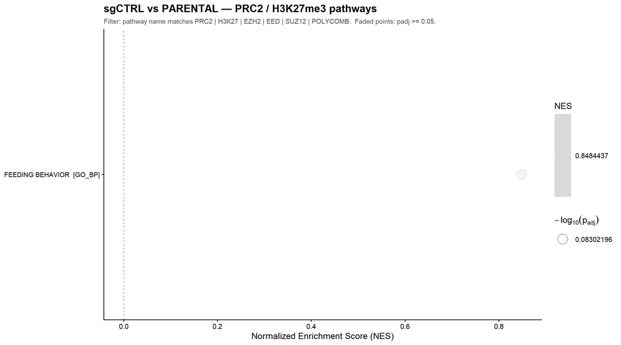

```
## Saved: gsea_prc2_sgCTRL_v_PARENTAL.(png|pdf)  [9x5 in]
```

## 12.7 TF activity panel (DoRothEA) — sgCTRL vs PARENTAL

```
## DoRothEA fgsea (sgCTRL vs PARENTAL): 239 TFs tested, 14 significant (padj<0.05)
```

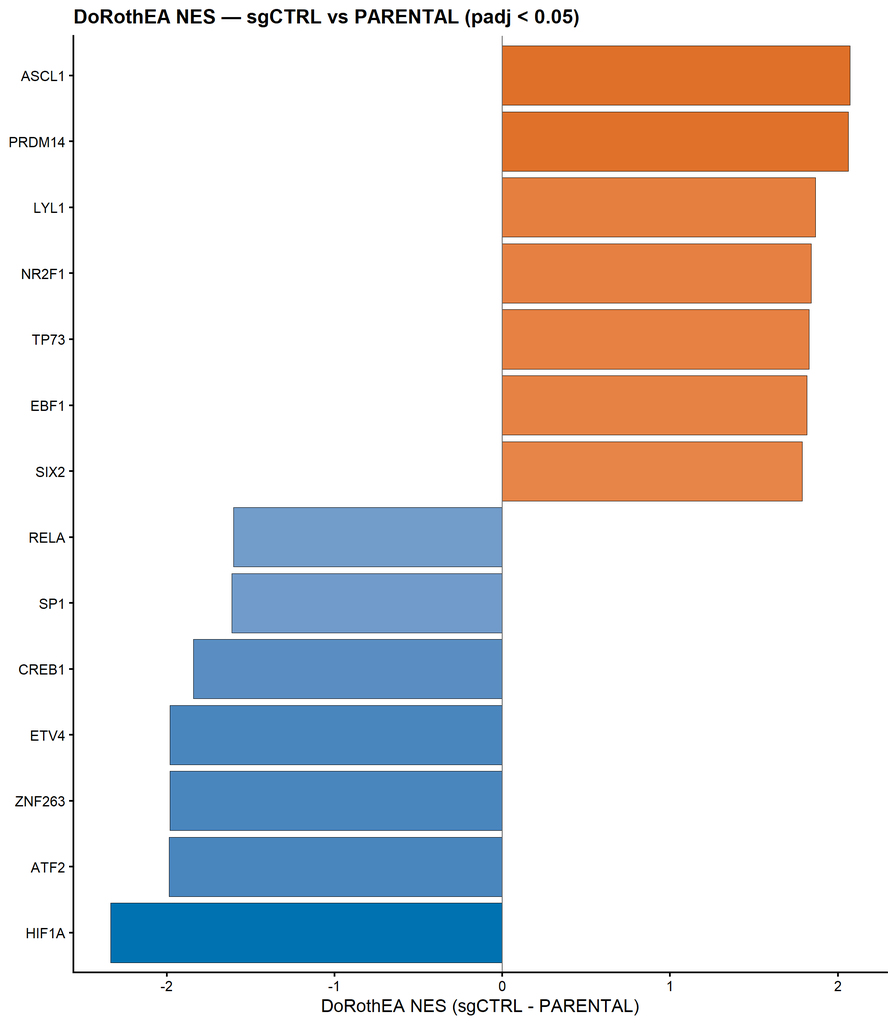

```
## Saved: tf_dorothea_bar_sgCTRL_v_PARENTAL.(png|pdf)  [7x8 in]
```

## 12.8 decoupleR contrast-level TF activity — sgCTRL vs PARENTAL

```
## decoupleR contrast ULM (sgCTRL vs PARENTAL): 660 TFs scored, 175 at p<0.05
```

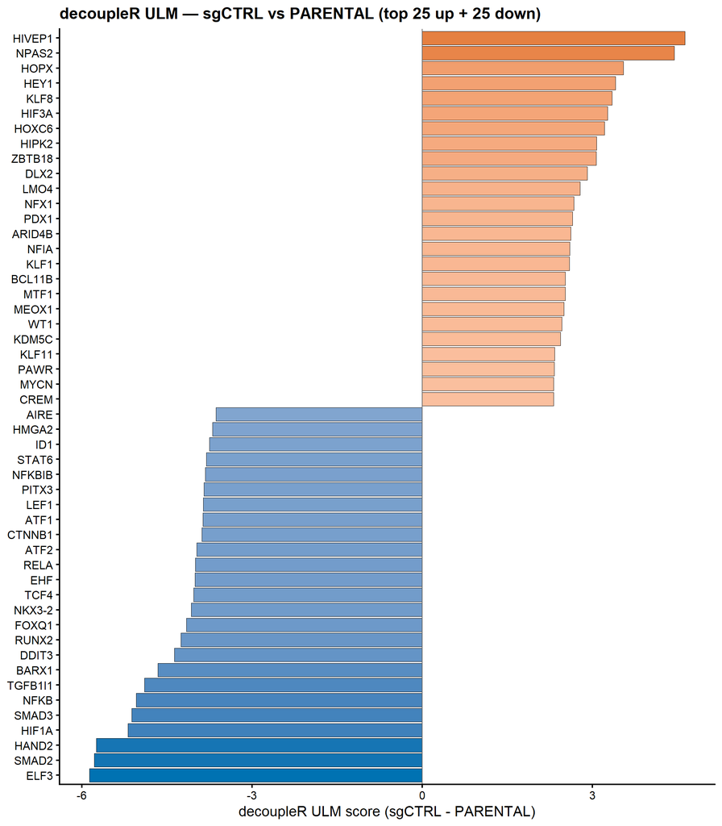

```
## Saved: decouple_TF_barplot_sgCTRL_v_PARENTAL.(png|pdf)  [7x8 in]
```

## 12.9 Verdict

```
## sgCTRL vs PARENTAL DEGs (FDR<0.05, |logFC|>0.75):       513
```

```
## sgCTRL vs PARENTAL significant pathways (padj<0.05): 290
```

```
## ...of which PRC2/H3K27 axis:                          0
```

```
## Significant TFs (DoRothEA, padj<0.05):                14
```

```
## Significant TFs (decoupleR contrast, p<0.05):         175
```

[output not shown]

# 13. msVIPER master-regulator analysis (all three contrasts)

Master-regulator inference via **msVIPER** (Alvarez et al., 2016) on the LOY-vs-sgCTRL, LOY-vs-pooled, and sgCTRL-vs-PARENTAL contrasts. Two regulon sources are run side-by-side:

1. **CollecTRI** (HGNC-keyed) — the same human regulome decoupleR uses (§9).
2. **TCGA-SARC ARACNe** (Entrez-keyed; `aracne.networks::regulonsarc`) — tissue-matched to HT1080 (fibrosarcoma).

Point estimates only (no bootstrap, shadow, or synergy) to keep render time manageable. Outputs feed the cross-source consistency analysis in §14.

## 13.1 Regulons + helpers

```
## CollecTRI regulon: 1186 TFs (median target size 9)
```

```
## TCGA-SARC ARACNe regulon (relabeled TF names to HGNC; targets remain Entrez): 4279 TFs (median target size 74)
```

```
## HGNC -> Entrez map: 14466 entries
```

## 13.2 LOY vs sgCTRL — canonical

### CollecTRI

```
## msVIPER CollecTRI (LOY vs sgCTRL): 257 TFs, 4 at FDR<0.05
```

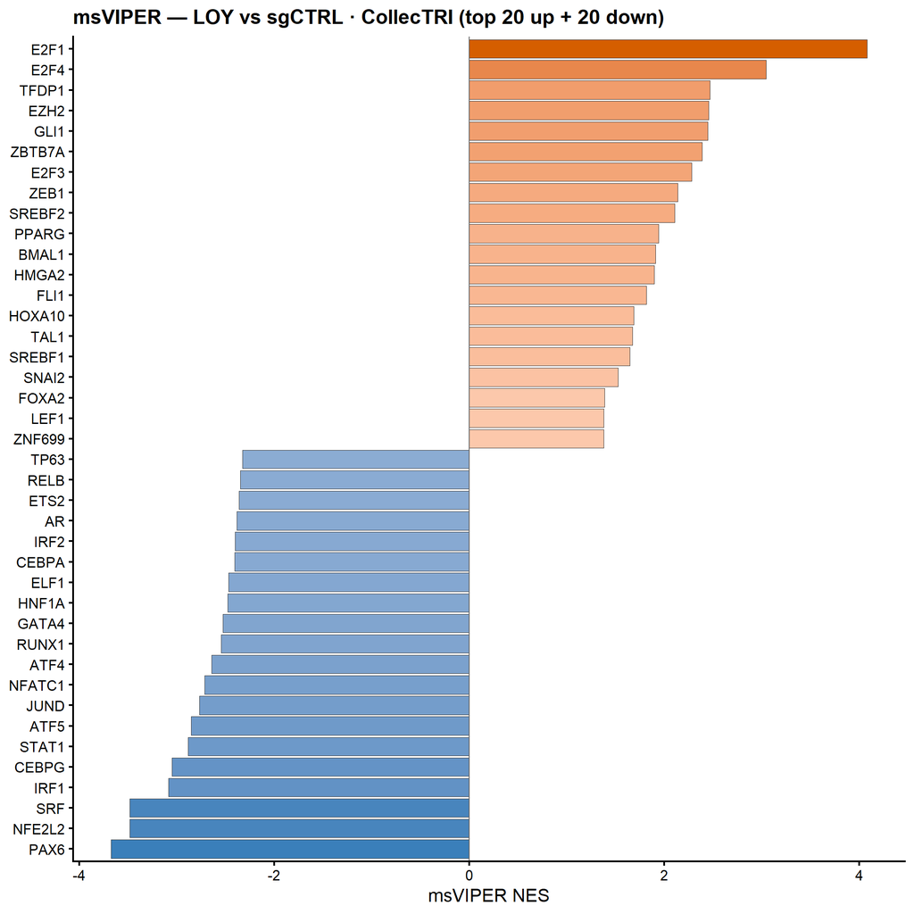

```
## Saved: msviper_bar_LOY_v_sgCTRL_collectri.(png|pdf)  [7x8 in]
```

### TCGA-SARC ARACNe

```
## msVIPER ARACNe (LOY vs sgCTRL): 3713 TFs, 128 at FDR<0.05
```

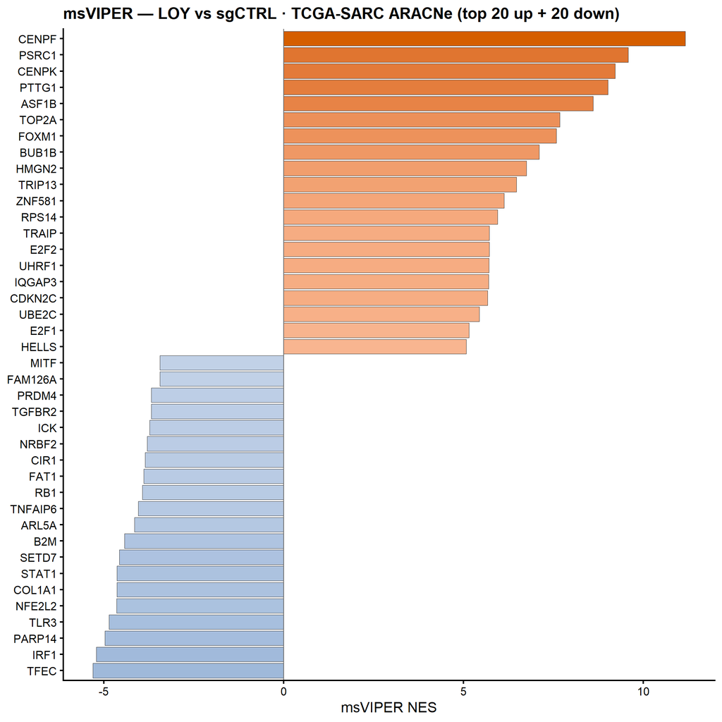

```
## Saved: msviper_bar_LOY_v_sgCTRL_aracne_sarc.(png|pdf)  [7x8 in]
```

## 13.3 LOY vs pooled Y+

### CollecTRI

```
## msVIPER CollecTRI (LOY vs pooled): 257 TFs, 7 at FDR<0.05
```

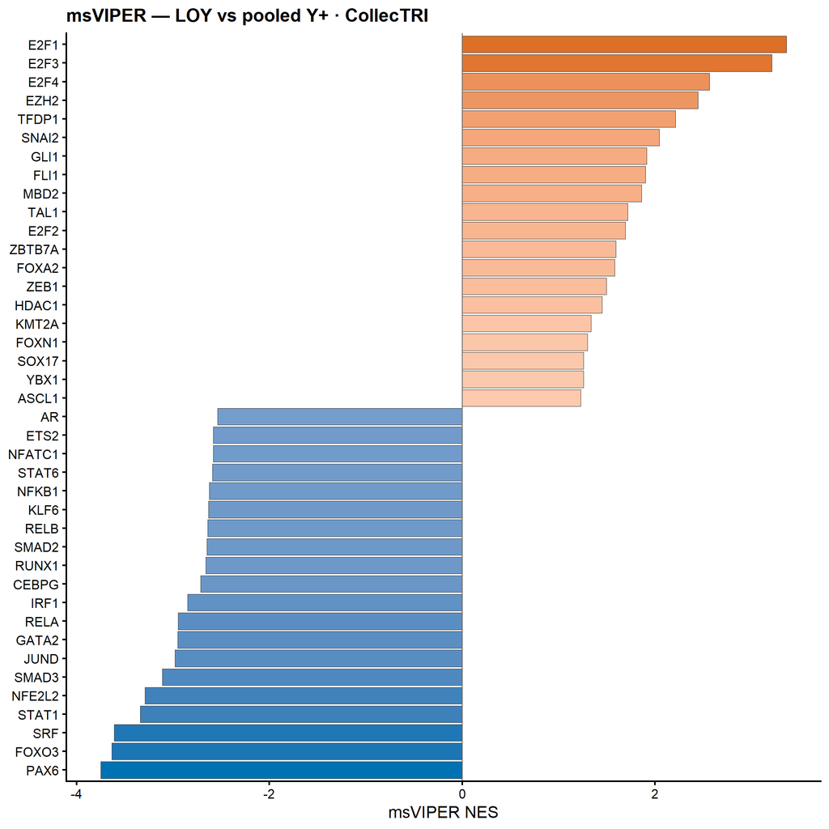

```
## Saved: msviper_bar_LOY_v_pooled_collectri.(png|pdf)  [7x8 in]
```

### TCGA-SARC ARACNe

```
## msVIPER ARACNe (LOY vs pooled): 3713 TFs, 127 at FDR<0.05
```

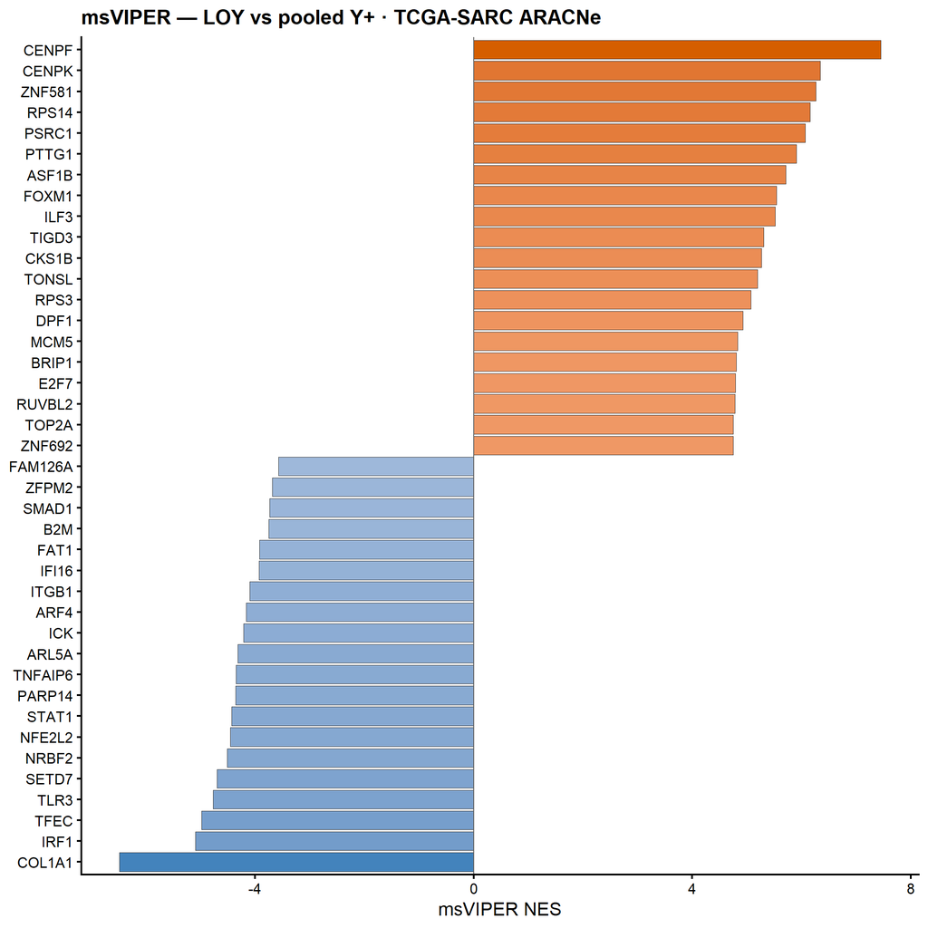

```
## Saved: msviper_bar_LOY_v_pooled_aracne_sarc.(png|pdf)  [7x8 in]
```

## 13.4 sgCTRL vs PARENTAL — sanity check

### CollecTRI

```
## msVIPER CollecTRI (sgCTRL vs PARENTAL): 257 TFs, 4 at FDR<0.05
```

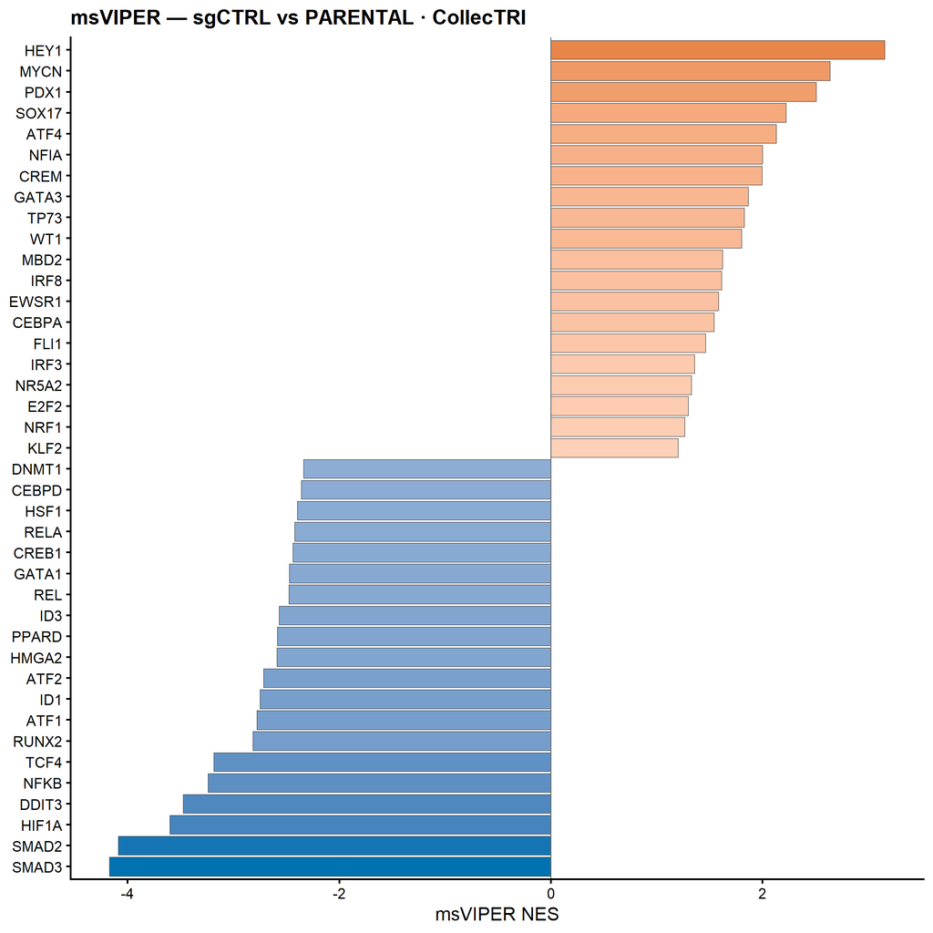

```
## Saved: msviper_bar_sgCTRL_v_PARENTAL_collectri.(png|pdf)  [7x8 in]
```

### TCGA-SARC ARACNe

```
## msVIPER ARACNe (sgCTRL vs PARENTAL): 3713 TFs, 42 at FDR<0.05
```

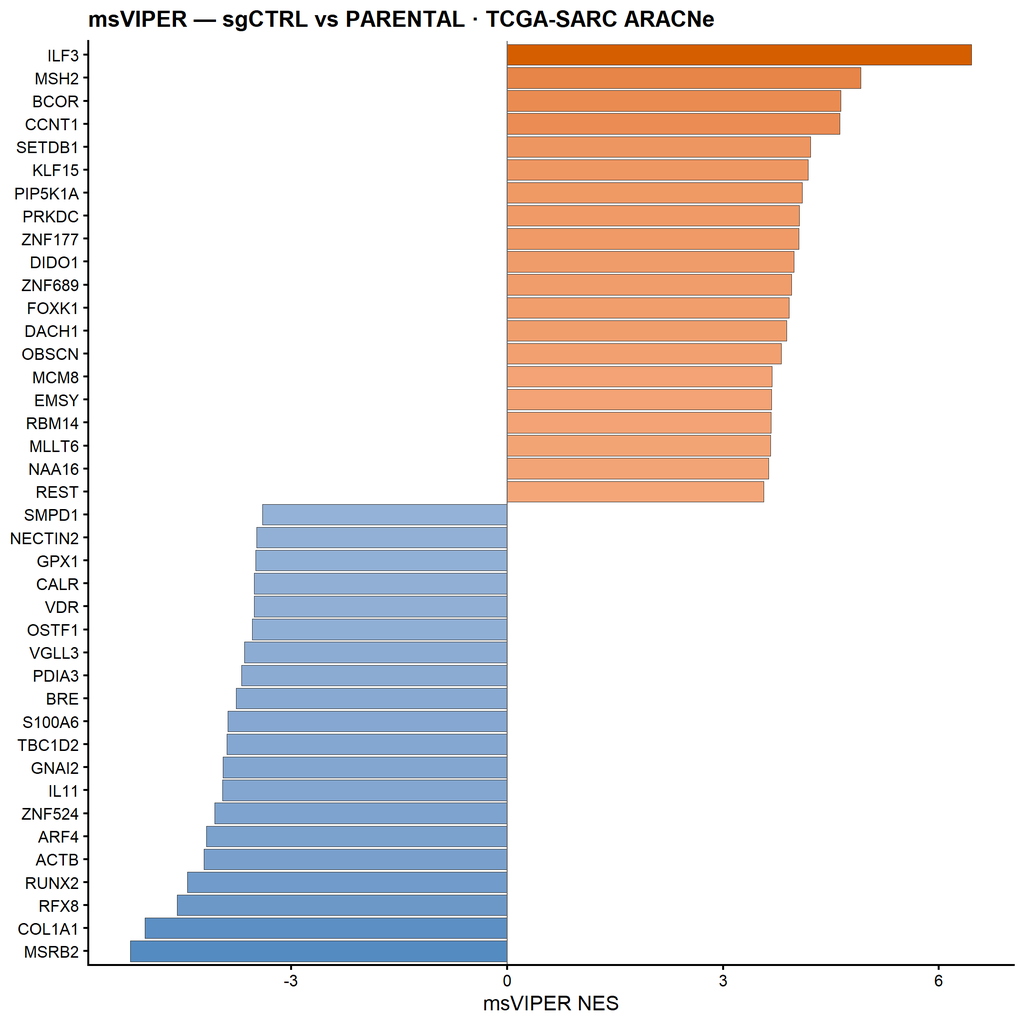

```
## Saved: msviper_bar_sgCTRL_v_PARENTAL_aracne_sarc.(png|pdf)  [7x8 in]
```

# 14. Cross-source TF consistency

This section integrates **every TF result generated above** — three contrasts (LOY-vs-sgCTRL, LOY-vs-pooled, sgCTRL-vs-PARENTAL) × four methods (DoRothEA fgsea, decoupleR ULM, msVIPER CollecTRI, msVIPER TCGA-SARC ARACNe) = up to 12 NES values per TF — and asks: **which TFs are consistently flagged across the LOY-relevant contrasts, and which are spuriously driven by a single method or the sgRNA control?**

A TF that scores highly in BOTH LOY contrasts (canonical + pooled) across multiple methods, AND is silent in the sgCTRL-vs-PARENTAL sanity check, is a robust master-regulator candidate. Conversely, TFs that score highly only in the sgCTRL-vs-PARENTAL contrast are sgRNA artifacts to discount.

## 14.1 Aggregate all TF NES results

TF result counts by contrast × source

| contrast | source | tested | sig |
| --- | --- | --- | --- |
| LOY_v_pooled | DoRothEA | 239 | 5 |
| LOY_v_pooled | decoupleR | 660 | 105 |
| LOY_v_pooled | msVIPER_ARACNe | 3713 | 127 |
| LOY_v_pooled | msVIPER_CollecTRI | 257 | 7 |
| LOY_v_sgCTRL | DoRothEA | 239 | 12 |
| LOY_v_sgCTRL | decoupleR | 660 | 141 |
| LOY_v_sgCTRL | msVIPER_ARACNe | 3713 | 128 |
| LOY_v_sgCTRL | msVIPER_CollecTRI | 257 | 4 |
| sgCTRL_v_PARENTAL | DoRothEA | 239 | 14 |
| sgCTRL_v_PARENTAL | decoupleR | 660 | 175 |
| sgCTRL_v_PARENTAL | msVIPER_ARACNe | 3713 | 42 |
| sgCTRL_v_PARENTAL | msVIPER_CollecTRI | 257 | 4 |

## 14.2 Consistency heatmap (top robust TFs)

Score each TF by how many of the **two LOY-relevant** source × contrast combinations it reaches significance in (max = 8: 4 sources × 2 LOY contrasts). Heatmap the NES of the top scorers across all 12 cells.

```
## TFs significant in >=3 LOY-relevant source x contrast cells: 13 (showing top 13)
```

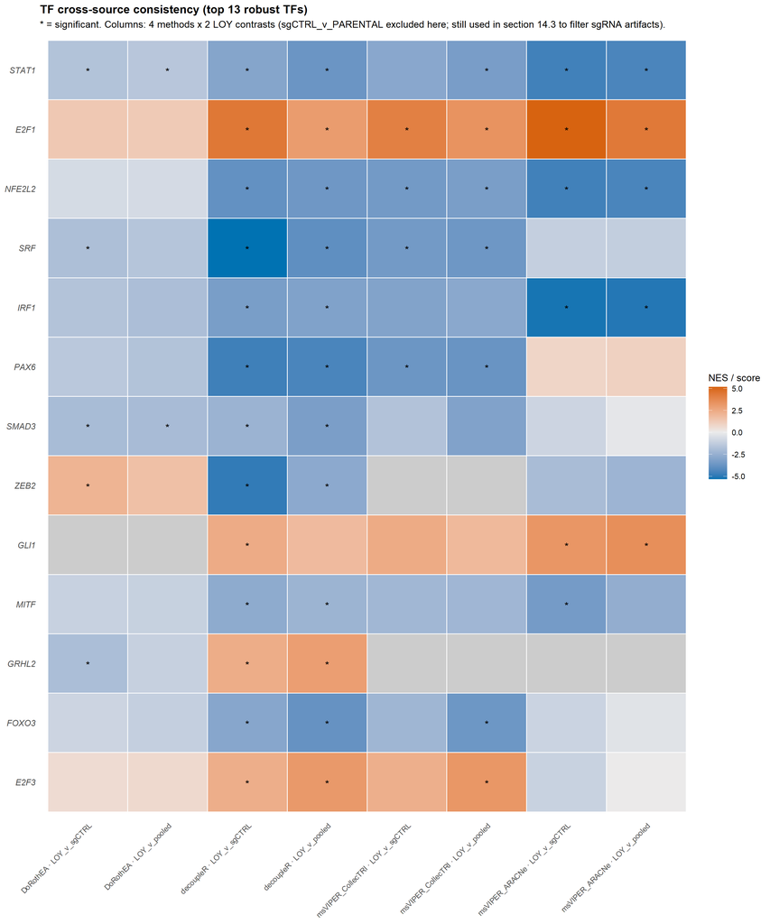

```
## Saved: tf_consistency_heatmap.(png|pdf)  [8x12 in]
```

## 14.3 Robust hits — TFs flagged by multiple sources in BOTH LOY contrasts and SILENT in sgCTRL-vs-PARENTAL

The cleanest robust hits: significant in BOTH LOY contrasts under at least two methods, NOT significant in sgCTRL-vs-PARENTAL (i.e., not an sgRNA artifact).

```
## Robust LOY TFs (>=2 sources in both LOY contrasts, silent in sgCTRL_v_PARENTAL): 5
```

Top 30 robust LOY TFs (>=2 methods agree in both LOY contrasts; not artifacts of sgRNA control)

| TF | sig_count | NES_direction_mean | sources_LOY_v_sgCTRL | sources_LOY_v_pooled |
| --- | --- | --- | --- | --- |
| E2F1 | 6 | 3.37 | decoupleR, msVIPER_CollecTRI, msVIPER_ARACNe | decoupleR, msVIPER_CollecTRI, msVIPER_ARACNe |
| NFE2L2 | 6 | -3.09 | decoupleR, msVIPER_CollecTRI, msVIPER_ARACNe | decoupleR, msVIPER_CollecTRI, msVIPER_ARACNe |
| SRF | 5 | -2.79 | DoRothEA, decoupleR, msVIPER_CollecTRI | decoupleR, msVIPER_CollecTRI |
| IRF1 | 4 | -3.28 | decoupleR, msVIPER_ARACNe | decoupleR, msVIPER_ARACNe |
| PAX6 | 4 | -2.24 | decoupleR, msVIPER_CollecTRI | decoupleR, msVIPER_CollecTRI |